# Evaluation of different phyllosphere sample types for parallel metabarcoding of Fungi and Oomycetes in Vitis vinifera

Falk Behrens

2022-02-07

# Methods

Leaf wash sediments (W) and leaf disks (L) are used to characterize the mycobiome of the Vitis vinifera phyllosphere by metabarcoding. Both sample types were processed from each leaf pool. Eighteen fully expanded Vitis vinifera cv. Müller-Thurgau leaves per leaf pool were collected at two sampling time points (02.06.2020 (N1) and 30.06.2020(N2)) at an experimental vineyard located near Neustadt an der Weinstraße, Germany. At each time point leaves of untreated (K1-3), Sulfur (S1-3) treated, or Sulphur and Copper (Cu1-3) treated vines were sampled in three repetitions from randomized Blocks resulting in 18x2 amplicon libraries. Leaf disks (one per leaf; 18 per leaf pool) were cut before washing. Negative controls for DNA extraction (K) and template free library preparation (BPCR) as well as an artificial mock community containing equal amounts of DNA from twelve different in vitro cultivated fungal species (Mock: Fomitiporia mediterranea; Sterum hirsutum; Bjerkandera adusta; Botytis cinerea; Aureobasidium pullulans; Gibellulopsis nigrescens; Phaeoacremonium angustius; Fusarium avenaceum; Fusarium culmorum; Aspergillus ochraceus; Phaeomoniella clamydospora; Pichia kluyveri) were included. A metabarcoding strategy capable of detecting Fungi and Oomycetes by using the ITS1catta/ITS2ngs (Tedersoo et al. 2017; Tedersoo and Anslan, 2019) primer combination for ITS1 library preparation was applied. Library preparation and sequencing were carried out by AllGenetics & Biology SL (www.allgenetics.eu). …

# Libraries

```r
library(tidyverse)
library(phyloseq)
library(multcomp)
library(ggpubr)
library(vegan)
library(ranacapa)
library(cowplot)
library(emmeans)
library(ggpmisc)
library(lme4)
library(biostat)
library(DESeq2)
```

# Make directory for figures

```r
dir.create("Figures")
```

# External Functions

### Filtering by negative controls with run_galan()

##### [cpauvert/phyloseq_galan.R](https://gist.github.com/cpauvert)

```r
# Filtering out contaminants with control samples (Galan et al. 2016)
  # Methods: Galan et al. (2016) doi:10.1128/mSystems.00032-16
  # Implementation: Charlie Pauvert
  # 2018-09-21


  # Visualize rapidly the filtered OTU (or ASV) table
  viz_matrix<-function(m,axes=T, xlab=NULL, ylab=NULL,...){
    mviz<-t(m) > 0
    image( mviz[,rev(1:ncol(mviz))], xaxt= "n", yaxt= "n", col = c("white","black"),useRaster = T,...)
    if(axes){
      axis( 1, at=seq(0,1,length.out=ncol( m ) ), labels= colnames( m ), las= 2 )
      axis( 2, at=seq(0,1,length.out=nrow( m ) ), labels= rev(rownames( m )), las= 2)
    }
    if(!is.null(xlab)) mtext(xlab,side = 1)
    if(!is.null(ylab)) mtext(ylab,side = 2)
  }


  # Run the filters
  run_galan<-function(physeq=NULL, ctrl_smp=NULL, positive=NULL, positive_smp=NULL,plot=TRUE){
    if(any(is.null(physeq),is.null(ctrl_smp))){
      stop("physeq or ctrl_cmp is NULL")
    } else {

      message("Threshold T_CC : filtering for cross-contamination")
      # Find the maximum number of sequences for an ASV in the
      # negative and positive controls samples
      if(!is.null(positive) & !is.null(positive_smp)){
        # Check if positives samples exists and ASV are given
        positive<-positive[positive %in% taxa_names(physeq)]
        # Fetch only ASV table of the control samples
        ctrl<-prune_samples(c(ctrl_smp,positive_smp),physeq)
        # # And removed the positive control ASVs
        # ctrl<-prune_taxa(!taxa_names(ctrl) %in% positive,ctrl)
      } else {
        # Fetch only negative control samples
        ctrl<-prune_samples(ctrl_smp,physeq)
      }
      m.ctrl<-as(otu_table( ctrl ), "matrix")


      # T_CC threshold for each ASV in the control samples
      mar<-ifelse(taxa_are_rows(physeq), 1 , 2)
      threshold.ctrl<-apply(m.ctrl,mar,max)


      if(!is.null(positive)){
        # Positive control ASVs should not be filtered
        threshold.ctrl[ names(threshold.ctrl) %in% positive]<-0
      }

      # Define a function to relevel ASV to 0 according to a ASV wise threshold.
      adaptative_threshold<-function(physeq, ASVThreshold){
        # Fetch ASV table
        ASV<-otu_table(physeq)
        # set margin depending on ASV orientation: row or column
        taxMargin<-ifelse( taxa_are_rows(ASV), 1, 2)
        # remove the number of sequences indicated in ASVThreshold
        # by samples for each ASV
        ASV.sweeped<-sweep(ASV, taxMargin, ASVThreshold+1, "-")
        # any ASV abundance negative was hence below the threshold
        # and therefore set to NA
        ASV.sweeped[ which(ASV.sweeped < 0) ]<-NA
        # Re balance the altered abundance by adding the previously
        # removed threshold. Note that NA are not affected
        ASV.sweeped<-sweep(ASV.sweeped, taxMargin, ASVThreshold+1,"+")
        # ASV that are NA are set to 0 and considered absent.
        ASV.sweeped[which(is.na(ASV.sweeped))]<-0
        # Return the corrected ASV table
        otu_table(physeq)<-otu_table(ASV.sweeped,
                                     taxa_are_rows = taxa_are_rows(ASV))
        return(physeq)
      }

      # Keep the initial ASV table
      initM<-as(otu_table( physeq ), "matrix")
      # Apply the threshold to the ASV table
      physeq<-adaptative_threshold(physeq, threshold.ctrl)
      # Compute the number of cells where the filter occurred
      finalM<-as(otu_table( physeq ), "matrix")
      # Wherever the value is negative, the filter occurred
      finalM<-finalM - initM < 0
      if(plot){
        # Plot the results
        (viz_matrix(finalM,axes=F,main="Threshold T_CC : filtering for cross-contamination"))
      }
      message(paste("Ranges of the T_CC treshold:", min(threshold.ctrl),max(threshold.ctrl)))

      if(!is.null(positive) & !is.null(positive_smp)){
        message("\n\nThreshold T_FA : filtering out incorrectly assigned sequences.")
        positive<-positive[positive %in% taxa_names(physeq)]
        # Identification of the maximal number of sequences of "alien" ASV
        # assigned to environmental samples
        alien.max<-max(otu_table(physeq)[positive,! sample_names(physeq) %in% positive_smp])
        # Find which ASV had the maximum values (because the above drops names)
        alien.max.otu<-rownames(which(otu_table(physeq)[positive,! sample_names(physeq) %in% positive_smp] == alien.max,arr.ind = T))
        message(paste("Max alien sequence number:",alien.max))
        message(paste(" identified with the following ASV:",alien.max.otu))

        # False-assignment rate R_fa
        alien.ratio<-alien.max / sum(taxa_sums(physeq)[alien.max.otu])
        message(paste("Alien sequence ratio (R_fa):", scales::percent(alien.ratio)))

        # Number of sequences potentially misassigned to their samples for each ASV (
        # Threshold T_fa
        threshold.alien<-taxa_sums(physeq) * alien.ratio
        message(paste("Ranges of the T_FA treshold:", min(threshold.alien),round(max(threshold.alien))))

        initM<-as(otu_table( physeq ), "matrix")

        # Apply the T_fa threshold
        physeq<-adaptative_threshold(physeq, threshold.alien)

        # Compute the number of cells where the filter occurred
        finalM<-as(otu_table( physeq ), "matrix")
        # Wherever the value is negative, the filter occurred
        finalM<-finalM - initM < 0
        if(plot){
          # Plot the results
          (viz_matrix(finalM,axes=F,main="Threshold T_FA : filtering out incorrectly assigned sequences."))
        }
      }
      message("\n\nThe removal of the control samples and the control ASV is NOT done within this function!")
      message("\n\nPlease cite Galan et al. (2016) doi:10.1128/mSystems.00032-16")
      return(physeq)
    }
  }
  #
  # Example of use of the function
  #

  # ASV identifiers of the positive control ASV of the strain.
  # marine.strains<-c(rep('Yamadazyma barbieri',3),rep('Candida oceani',2))
  # names(marine.strains)<-c("e3b29fe75256a310e2712678e84612826b584728",
  #                          "8dd49297074e132374a68ef5219244b0fc512826",
  #                          "3723dfe3dec2cdebeef00493920371525866ad55",# Yama
  #                          "af9d85218cd86808f881938898ad184945244cb0",
  #                          "e37aa309d50c33ef3c5b5521540f762e06cf0b10")

  # Applying Galan filters using two thresholds T_CC and T_FA
  #
  # run_one_filtered<-run_galan(physeq = run_one,
  #                    ctrl_smp = c("B.poole","T.PCR"),
  #                    positive = names(marine.strains),
  #                    positive_smp = c("TplusPCR", "Tplus.ePCR"))

  # Example of output by the function
  #
  # Threshold T_CC : filtering for cross-contamination
  # Ranges of the T_CC treshold: 0 158
  #
  #
  # Threshold T_FA : filtering out incorrectly assigned sequences.
  # Max alien sequence number: 310
  #  identified with the following ASV: e3b29fe75256a310e2712678e84612826b584728
  # Alien sequence ratio (R_fa): 0.371%
  # Ranges of the T_FA treshold: 0 8946
  #
  #
  # The removal of the control samples and the control ASV is NOT done within this function!
  #
  #
  #   Please cite Galan et al. (2016) doi:10.1128/mSystems.00032-16
```

### Rarecurves with ggrare() (modified)

##### gauravsk/ranacapa

```r
# Rareplots
# Linetype and dot arguments were included in for plotting
# Plot rarefaction curves
ggrare <- function(physeq, step = 10, label = NULL, color = NULL, linetype = NULL, plot = TRUE, parallel = FALSE, se = TRUE, dot = FALSE) {
  ## Args:
  ## - physeq: phyloseq class object, from which abundance data are extracted
  ## - step: Step size for sample size in rarefaction curves
  ## - label: Default `NULL`. Character string. The name of the variable
  ##          to map to text labels on the plot. Similar to color option
  ##          but for plotting text.
  ## - linetype: Default `NULL`. Character string. The name of the variable
  ##          to map to linetypes on the plot. Similar to color option
  ##          but for plotting different linetypes.
  ## - color: (Optional). Default 'NULL'. Character string. The name of the
  ##          variable to map to colors in the plot. This can be a sample
  ##          variable (among the set returned by
  ##          'sample_variables(physeq)' ) or taxonomic rank (among the set
  ##          returned by 'rank_names(physeq)').
  ##
  ##          Finally, The color scheme is chosen automatically by
  ##          'link{ggplot}', but it can be modified afterward with an
  ##          additional layer using 'scale_color_manual'.
  ## - color: Default `NULL`. Character string. The name of the variable
  ##          to map to text labels on the plot. Similar to color option
  ##          but for plotting text.
  ## - plot:  Logical, should the graphic be plotted.
  ## - parallel: should rarefaction be parallelized (using parallel framework)
  ## - se:    Default TRUE. Logical. Should standard errors be computed.
  ## require vegan
  x <- as(otu_table(physeq), "matrix")
  if (taxa_are_rows(physeq)) { x <- t(x) }

  ## This script is adapted from vegan `rarecurve` function
  tot <- rowSums(x)
  S <- rowSums(x > 0)
  nr <- nrow(x)

  rarefun <- function(i) {
    cat(paste("rarefying sample", rownames(x)[i]), sep = "\n")
    n <- seq(1, tot[i], by = step)
    if (n[length(n)] != tot[i]) {
      n <- c(n, tot[i])
    }
    y <- rarefy(x[i, ,drop = FALSE], n, se = se)
    if (nrow(y) != 1) {
      rownames(y) <- c(".S", ".se")
      return(data.frame(t(y), Size = n, Sample = rownames(x)[i]))
    } else {
      return(data.frame(.S = y[1, ], Size = n, Sample = rownames(x)[i]))
    }
  }
  if (parallel) {
    out <- mclapply(seq_len(nr), rarefun, mc.preschedule = FALSE)
  } else {
    out <- lapply(seq_len(nr), rarefun)
  }
  df <- do.call(rbind, out)

  ## Get sample data
  if (!is.null(sample_data(physeq, FALSE))) {
    sdf <- as(sample_data(physeq), "data.frame")
    sdf$Sample <- rownames(sdf)
    data <- merge(df, sdf, by = "Sample")
    labels <- data.frame(x = tot, y = S, Sample = rownames(x))
    labels <- merge(labels, sdf, by = "Sample")
  }

  ## Add, any custom-supplied plot-mapped variables
  if( length(color) > 1 ){
    data$color <- color
    names(data)[names(data)=="color"] <- deparse(substitute(color))
    color <- deparse(substitute(color))
  }
  if( length(label) > 1 ){
    labels$label <- label
    names(labels)[names(labels)=="label"] <- deparse(substitute(label))
    label <- deparse(substitute(label))
  }

  p <- ggplot(data = data, aes_string(x = "Size", y = ".S", group = "Sample", color = color))
  p <- p + labs(x = "Sample Size", y = "Species Richness")
  if (!is.null(label)) {
    p <- p + geom_text(data = labels, aes_string(x = "x", y = "y", label = label, color = color),
                       size = 4, hjust = 0)
  }
  p <- p + geom_line(mapping = aes_string(linetype = linetype), size = 0.5)
  if (se) { ## add standard error if available
    p <- p + geom_ribbon(aes_string(ymin = ".S - .se", ymax = ".S + .se", color = NULL, fill = color), alpha = 0.2)
  }
  if (!is.null(dot)) {
    p <- p + geom_point(data = labels, aes_string(x = "x", y = "y", fill = dot), shape = 21, color = "black", size = 2)
  }
  if (plot) {
    plot(p)
  }
  invisible(p)
}
```

# Prepare ASV physeqs

### Load metabarcoding and sample data

```r
## summarize physeq data
# Set path for working directory
path <- getwd()

# merged tables
table <- sort(list.files(path, pattern = "merged.table", full.names = TRUE))
table
```

```
## [1] "/home/falk.behrens/Schreibtisch/MetaOomy/phyllo_meta_fungi/ASV.merged.table.txt"
```

```r
# sampledata
sampletab <- list.files(path, pattern = "samplelist", full.names = TRUE)
sampletab
```

```
## [1] "/home/falk.behrens/Schreibtisch/MetaOomy/phyllo_meta_fungi/samplelist.txt"
```

### Make ASV physeq list

```r
# Physeq list
ASV <- list()

# load table from DADA2 analysis
ASV[["merged.table"]] <- read.table(table, sep="\t", header = TRUE)

# make sequence tbl to create fasta
ASV[["blast.table"]] <- data.frame(ID = rownames(ASV[["merged.table"]]), Sequence = ASV[["merged.table"]]$Sequence)

# make sampletab
ASV[["sampledata"]] <- sample_data(data.frame(read.table(sampletab, header= TRUE, sep="\t", dec=","), stringsAsFactors=FALSE))

# make basic.physeq
ASV[["basic.physeq"]] <- phyloseq(otu_table(as(ASV[["merged.table"]][ ,c(1:(length(colnames(ASV[["merged.table"]]))-9))], "matrix"), taxa_are_rows = TRUE), tax_table(as(ASV[["merged.table"]][,c((length(colnames(ASV[["merged.table"]]))-8):(length(colnames(ASV[["merged.table"]]))-1))], "matrix")), ASV[["sampledata"]])

# neg.filt.physeq
ASV[["neg.filt.physeq"]] <- run_galan(physeq = ASV[["basic.physeq"]], ctrl_smp = rownames(ASV[["sampledata"]][ASV[["sampledata"]]$Treatment == "negative"]), plot = FALSE)
ASV[["neg.filt.physeq"]] <- prune_samples(!sample_names(ASV[["neg.filt.physeq"]]) %in% rownames(ASV[["sampledata"]][ASV[["sampledata"]]$Treatment == "negative"]), ASV[["neg.filt.physeq"]])
ASV[["neg.filt.physeq"]] <- prune_taxa(taxa_sums(ASV[["neg.filt.physeq"]]) > 0, ASV[["neg.filt.physeq"]])

# mock.physeq
ASV[["mock.physeq"]] <- subset_samples(ASV[["neg.filt.physeq"]], Treatment == "positive")
ASV[["mock.physeq"]] <- prune_taxa(taxa_sums(ASV[["mock.physeq"]]) > 0, ASV[["mock.physeq"]])

# sample.physeq
ASV[["sample.physeq"]] <- subset_samples(ASV[["neg.filt.physeq"]], Sampletype != "Control" )
ASV[["sample.physeq"]] <- prune_taxa( taxa_sums(ASV[["sample.physeq"]]) > 0, ASV[["sample.physeq"]])
```

### Function to filter ASVs based on abundance in n samples

```r
filter_abundance <- function(physeq, quant = 2, samp = 2/36){
  filt = genefilter_sample(physeq, filterfun_sample(function(x) x >= quant), A=(samp)*nsamples(physeq))
  new = prune_taxa(filt, physeq)
  return(new)
}
```

### Filter physeq by ASV occurrence and taxa

```r
# Filtering
physeq <- ASV[["sample.physeq"]]
physeq
```

```
## phyloseq-class experiment-level object
## otu_table()   OTU Table:         [ 2138 taxa and 36 samples ]
## sample_data() Sample Data:       [ 36 samples by 4 sample variables ]
## tax_table()   Taxonomy Table:    [ 2138 taxa by 8 taxonomic ranks ]
```

```r
physeq <- subset_taxa(physeq, Kingdom != "Unknown")
physeq
```

```
## phyloseq-class experiment-level object
## otu_table()   OTU Table:         [ 1717 taxa and 36 samples ]
## sample_data() Sample Data:       [ 36 samples by 4 sample variables ]
## tax_table()   Taxonomy Table:    [ 1717 taxa by 8 taxonomic ranks ]
```

```r
physeq.filt <- filter_abundance(physeq, samp = 2/36)
physeq.filt
```

```
## phyloseq-class experiment-level object
## otu_table()   OTU Table:         [ 612 taxa and 36 samples ]
## sample_data() Sample Data:       [ 36 samples by 4 sample variables ]
## tax_table()   Taxonomy Table:    [ 612 taxa by 8 taxonomic ranks ]
```

```r
# Fungi and Stramenopila
physeq.fungi <- subset_taxa(physeq.filt, Kingdom == "Fungi" | Kingdom == "Stramenopila")
physeq.fungi
```

```
## phyloseq-class experiment-level object
## otu_table()   OTU Table:         [ 518 taxa and 36 samples ]
## sample_data() Sample Data:       [ 36 samples by 4 sample variables ]
## tax_table()   Taxonomy Table:    [ 518 taxa by 8 taxonomic ranks ]
```

```r
sample_sums(physeq.fungi)
```

```
## N1Cu1L N1Cu1W N1Cu2L N1Cu2W N1Cu3L N1Cu3W  N1K1L  N1K1W  N1K2L  N1K2W  N1K3L
##   2493  16754  14784  14299   5827  11068   3749  13638   4681  10076  10618
##  N1K3W  N1S1L  N1S1W  N1S2L  N1S2W  N1S3L  N1S3W N2Cu1L N2Cu1W N2Cu2L N2Cu2W
##  11565  15710  18454  12825  14424  20321  11597  23211  25822  21853  22536
## N2Cu3L N2Cu3W  N2K1L  N2K1W  N2K2L  N2K2W  N2K3L  N2K3W  N2S1L  N2S1W  N2S2L
##  24900  25716  24005  21449  22256  27318  22573  20755  24920  27170  22920
##  N2S2W  N2S3L  N2S3W
##  25326  24563  25511
```

# Analyse ASV occurence

### Bar plot for sampletype dependent occurrence of ASVs

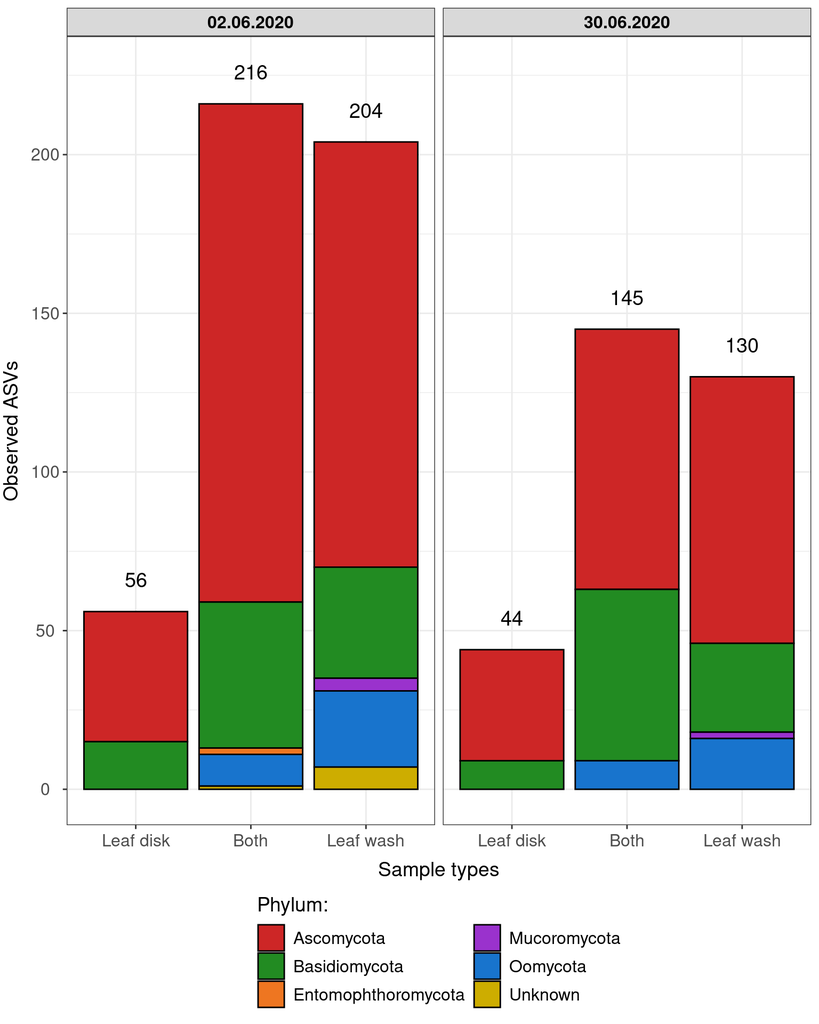

```r
otu.tab <- tibble(merge(data.frame(otu_table(physeq.fungi)) %>%
                          dplyr::select(seq(1,36,2)),
                        data.frame(otu_table(physeq.fungi)) %>%
                          dplyr::select(seq(2,36,2)),
                        by = "row.names"))
colnames(otu.tab)[1] <- "ID"
otu.tab <- left_join(otu.tab, data.frame(tax_table(physeq.fungi)),
                     by = "ID")

factor_groups <- seq(1,18,9)
sample.list <- list()

for (i in 1:length(factor_groups)) {
  x <- factor_groups[i]
  y <- x+1

  df <- tibble(otu.tab[1],
               leaf_disk = rowSums(otu.tab[,seq(y,y+8)]),
               leaf_wash = rowSums(otu.tab[,seq(y+18,y+26)]),
               otu.tab[c(39,44)])
  df[,6:8] <- "XXX"
  colnames(df)[6:8] <- c("sum", "occ", "Timepoint")

  # sum
  df[6] <- df[,2] + df[,3]
  df <- filter(df, sum != 0)
  #df <- filter(df, Phylum == "Ascomycota" | Phylum == "Basidiomycota" | Phylum == "Oomycota" )

  # specific occurence
  for (z in 1:nrow(df)){
    if(df[z,2] >= 1 && df[z,3] >= 1){
      df$occ[z] <- "Both"
    } else if(df[z,2] >= 1 && df[z,3] == 0){
      df$occ[z] <- "Leaf disk"
    } else if(df[z,2] == 0 && df[z,3] >= 1){
      df$occ[z] <- "Leaf wash"
    } else {
      print("Error in assignment of specific occurence")
    }
  }

  # Timepoint
  if(x == 1){
    df$Timepoint <- "2020_06_02"
  } else if(x == 10){
    df$Timepoint <- "2020_06_30"
  } else {
    print("Error in assign Timepoint")
  }

  sample.list[[i]] <- df
}

for (x in 1:2) {
  by_occ <- group_by(sample.list[[x]], occ, Phylum, Timepoint)
  sample.list[[x]] <- summarise(by_occ,
                                count = n())
}

occ.tab <- bind_rows(sample.list, .id = "sample")

by_occurrence <- group_by(occ.tab, Timepoint, occ)
occ_sum <- data.frame(summarise(by_occurrence,
                       count = sum(count)))

# New lables for Treatment
Treatment.labs <- c("Untreated\ncontrol", "Sulphur", "Sulphur +\nCopper")
names(Treatment.labs) <- c("Cont", "S", "S_Cu")

# New lables for Timepoint
Timepoint.labs <- c("02.06.2020", "30.06.2020")
names(Timepoint.labs) <- c("2020_06_02", "2020_06_30")

p3 <- ggplot(occ.tab, aes(x = factor(occ, levels = c("Leaf disk", "Both", "Leaf wash")), y = count, fill = Phylum))+
  geom_bar(stat = "identity", color = "black")+
  facet_wrap(~Timepoint, labeller = labeller(Timepoint = Timepoint.labs), ncol = 2)+

  labs(x="Sample types",
       y="Observed ASVs")+
  scale_fill_manual(name = "Phylum:",
                    values = c("firebrick3", "forestgreen", "chocolate2", "darkorchid3", "dodgerblue3", "gold3"))+

  geom_text(data = occ_sum, aes(x = factor(occ, levels = c("Leaf disk", "Both", "Leaf wash")), y = count+10, fill = NULL, label=count),
             color="black", size = 5)+

  guides(fill=guide_legend(direction = "vertical", ncol = 2))+

  theme_bw()+
  theme(strip.text.x = element_text(size = 12, color = "black", face = "bold"))+
  theme(axis.title.x = element_text(vjust= -1, size=14))+
  theme(axis.text.x = element_text(hjust = 0.5, vjust= 0.5, size = 12))+
  theme(axis.title.y = element_text(hjust = 0.5, vjust= 2, size = 14))+
  theme(axis.text.y = element_text(hjust = 0.5, vjust= 0.5, size = 12))+
  theme(legend.title = element_text(hjust = 0, vjust= 0.5, size = 14))+
  theme(legend.text = element_text(hjust = 0, vjust= 0.5, size = 12))+
  theme(legend.key.size = unit(0.7, "cm"))+
  theme(legend.spacing.x = unit(0.2, "cm"))+
  theme(legend.position= "bottom")

p3
```

```r
ggsave("./Figures/bar_plot.pdf", p3, width = 5, height = 7)
```

### Leaf disk ASVs

```r
prune_taxa(taxa_sums(subset_samples(physeq.fungi, Sampletype == "Leaf")) > 0, subset_samples(physeq.fungi, Sampletype == "Leaf"))
```

```
## phyloseq-class experiment-level object
## otu_table()   OTU Table:         [ 341 taxa and 18 samples ]
## sample_data() Sample Data:       [ 18 samples by 4 sample variables ]
## tax_table()   Taxonomy Table:    [ 341 taxa by 8 taxonomic ranks ]
```

### Leaf wash ASVs

```r
prune_taxa(taxa_sums(subset_samples(physeq.fungi, Sampletype == "Wash")) > 0, subset_samples(physeq.fungi, Sampletype == "Wash"))
```

```
## phyloseq-class experiment-level object
## otu_table()   OTU Table:         [ 485 taxa and 18 samples ]
## sample_data() Sample Data:       [ 18 samples by 4 sample variables ]
## tax_table()   Taxonomy Table:    [ 485 taxa by 8 taxonomic ranks ]
```

### Percent of Vitales sequences of Leaf disk samples

```r
sub_leaf_vitales <- subset_taxa(subset_samples(physeq.filt, Sampletype == "Leaf"), Order == "Vitales")
sum(data.frame(otu_table(sub_leaf_vitales)))/sum(data.frame(otu_table(subset_samples(physeq.filt, Sampletype == "Leaf"))))*100
```

```
## [1] 0.2881686
```

### Percent of Vitales sequences of Leaf wash samples

```r
sub_wash_vitales <- subset_taxa(subset_samples(physeq.filt, Sampletype == "Wash"), Order == "Vitales")
sum(data.frame(otu_table(sub_wash_vitales)))/sum(data.frame(otu_table(subset_samples(physeq.filt, Sampletype == "Wash"))))*100
```

```
## [1] 0
```

### Counting Phyla Abundances

```r
tax_tab <- data.frame(tax_table(physeq.filt))
nrow(tax_tab[tax_tab$Phylum == "Ascomycota",])
```

```
## [1] 350
```

```r
nrow(tax_tab[tax_tab$Phylum == "Basidiomycota",])
```

```
## [1] 117
```

```r
nrow(tax_tab[tax_tab$Phylum == "Oomycota",])
```

```
## [1] 37
```

# α-Diversity

### Function to make α-Diversity table

```r
make_alpha_table <- function(physeq = physeq){

  # Estimate diversity indices
  otu_df <- data.frame(otu_table(physeq))
  df <- data.frame(Sample = colnames(otu_df), row.names = colnames(otu_df))

  # Indices
  for (x in 1:ncol(otu_df)) {

    # sample column
    col <- otu_df[otu_df[,x] != 0,x]

    # Observed
    df$Observed[x] <- length(col)

    # Shannon
    value <- 0
    for (z in 1:length(col)){
      value <- value + (col[z]/sum(col))*log(col[z]/sum(col))*-1
    }
    df$Shannon[x] <- value

    # Pielou's evenness
    df$Evenness[x] <- df$Shannon[x]/log(df$Observed[x])

    # InvSimpson
    value <- 0
    for (z in 1:length(col)){
      value <- value + (col[z]/sum(col))^2
    }
    df$InvSimpson[x] <- 1/value
  }
  df <- merge(df, data.frame(data.frame(sample_data(physeq))), by  = "row.names")
  df$Row.names <- NULL
  return(df)
}
```

### Make α-Diversity table

```r
alpha_table <- make_alpha_table(physeq.fungi)
alpha_table$Combi <- as.factor(paste(alpha_table$Sampletype, alpha_table$Timepoint, sep = "_"))
alpha_table <- alpha_table[order(alpha_table$Treatment),]
alpha_table <- alpha_table[order(alpha_table$Sampletype),]
alpha_table <- alpha_table[order(alpha_table$Timepoint),]
head(alpha_table)
```

```
##    Sample Observed  Shannon  Evenness InvSimpson Sampletype  Timepoint
## 7   N1K1L       57 2.625967 0.6495013   6.111861       Leaf 2020_06_02
## 9   N1K2L       51 2.197814 0.5589806   4.857838       Leaf 2020_06_02
## 11  N1K3L       54 1.968843 0.4935700   3.853215       Leaf 2020_06_02
## 13  N1S1L       83 2.363670 0.5349073   3.850199       Leaf 2020_06_02
## 15  N1S2L       75 2.397111 0.5552097   4.233357       Leaf 2020_06_02
## 17  N1S3L       80 2.266447 0.5172144   3.732032       Leaf 2020_06_02
##    Treatment Block           Combi
## 7       Cont     1 Leaf_2020_06_02
## 9       Cont     2 Leaf_2020_06_02
## 11      Cont     3 Leaf_2020_06_02
## 13         S     1 Leaf_2020_06_02
## 15         S     2 Leaf_2020_06_02
## 17         S     3 Leaf_2020_06_02
```

### Plot rarefaction curves

```r
rASV <- ggrare(physeq.fungi, step = 50, label = NULL, color = "Sampletype", linetype = "Timepoint",
               plot = FALSE, parallel = FALSE, se = FALSE, dot = "Treatment")+

  annotate(geom = "text", x = 0.5, y = 195, label = "A)",
           vjust = 0, hjust = 0, fontface='bold', size = 10)+

  scale_x_continuous(limits = c(0,30000))+
  scale_y_continuous(limits = c(0,200))+
  labs(x= "Sequencing depth (reads)", y = "Observed ASVs")+

  scale_color_manual(name = "Sample type:",
                     values = c("limegreen", "dodgerblue2"),
                     labels = c("Leaf disk", "Leaf wash"))+

  scale_linetype_discrete(name="Sampling time point:",
                          labels = c("02.06.2020", "30.06.2020"))+

  scale_fill_manual(name = "Treatment:",
                    values = c("forestgreen","darkgoldenrod1","cornflowerblue"),
                    labels = c("Untreated\ncontrol", "Sulphur", "Sulphur +\nCopper"))+

  guides(color=guide_legend(override.aes = list(size = 1),
                            direction = "horizontal", nrow = 1),
         linetype=guide_legend(override.aes = list(size = 1),
                               direction = "horizontal", nrow = 1),
         fill=guide_legend(override.aes = list(size = 4),
                           direction = "horizontal", nrow = 1))+

  theme_bw()+
  theme(plot.title = element_text(hjust = 0.5, vjust = 0, size = 16))+
  theme(axis.text.x = element_text(angle = +0, hjust = 0.5, vjust= 0, size = 12))+
  theme(axis.text.y = element_text(angle = +0, hjust = 0, vjust= 0.5, size = 12))+
  theme(axis.title.x = element_text(angle = +0, hjust = 0.5, vjust= 0, size = 14))+
  theme(axis.title.y = element_text(angle = +90, hjust = 0.5, vjust= 2, size = 14))+
  theme(legend.title = element_text(hjust = 0, vjust= 0.5, size = 14))+
  theme(legend.text = element_text(hjust = 0, vjust= 0.5, size = 12))+
  theme(legend.background = element_blank())+
  theme(legend.key.size = unit(1, "cm"))+
  theme(legend.spacing.y = unit(-0.2, "cm"))+
  theme(legend.position= c(0.55,0.125))
```

```
## rarefying sample N1Cu1L
## rarefying sample N1Cu1W
## rarefying sample N1Cu2L
## rarefying sample N1Cu2W
## rarefying sample N1Cu3L
## rarefying sample N1Cu3W
## rarefying sample N1K1L
## rarefying sample N1K1W
## rarefying sample N1K2L
## rarefying sample N1K2W
## rarefying sample N1K3L
## rarefying sample N1K3W
## rarefying sample N1S1L
## rarefying sample N1S1W
## rarefying sample N1S2L
## rarefying sample N1S2W
## rarefying sample N1S3L
## rarefying sample N1S3W
## rarefying sample N2Cu1L
## rarefying sample N2Cu1W
## rarefying sample N2Cu2L
## rarefying sample N2Cu2W
## rarefying sample N2Cu3L
## rarefying sample N2Cu3W
## rarefying sample N2K1L
## rarefying sample N2K1W
## rarefying sample N2K2L
## rarefying sample N2K2W
## rarefying sample N2K3L
## rarefying sample N2K3W
## rarefying sample N2S1L
## rarefying sample N2S1W
## rarefying sample N2S2L
## rarefying sample N2S2W
## rarefying sample N2S3L
## rarefying sample N2S3W
```

### GLMM of ASV richness

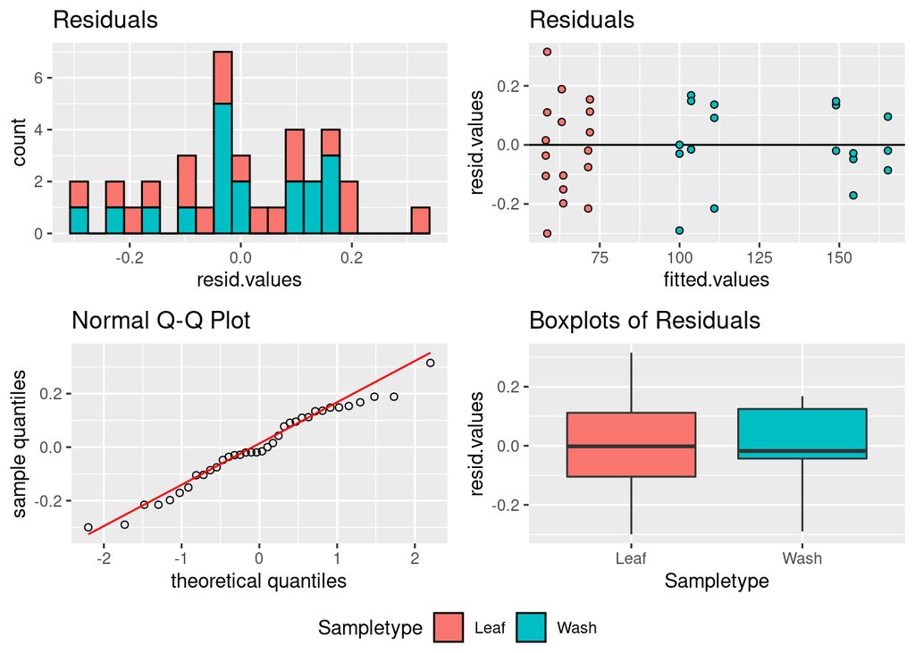

```r
glmm.mod <- glmer.nb(Observed ~ Sampletype*(Timepoint+Treatment)+(1|Block),
                     data = alpha_table)

# Check model
alpha_table$resid.values <- resid(glmm.mod, type = "working")
alpha_table$fitted.values <- fitted(glmm.mod)

p1 <- ggplot(alpha_table, aes(x=resid.values, fill = Sampletype))+
  geom_histogram(color = "black", bins = 20)+
  labs(title="Residuals")
p2 <- ggplot(alpha_table, aes(x=fitted.values, y=resid.values, fill = Sampletype))+
  geom_hline(aes(yintercept = 0))+
  geom_point(shape = 21)+
  scale_shape_manual(values = c(21,22))+
  labs(title="Residuals")
p3 <- ggplot(alpha_table, aes(sample=resid.values))+
  stat_qq(shape = 21)+
  stat_qq_line(col = "red")+
  labs(title="Normal Q-Q Plot",
       y= "sample quantiles",
       x= "theoretical quantiles")
p4 <- ggplot(alpha_table, aes(x = Sampletype, y=resid.values, fill = Sampletype))+
  geom_boxplot()+
  labs(title="Boxplots of Residuals")
ggarrange(p1,p2,p3,p4, common.legend = TRUE, legend = "bottom")
```

```r
# ANOVA
car::Anova(glmm.mod)
```

```
## Analysis of Deviance Table (Type II Wald chisquare tests)
##
## Response: Observed
##                         Chisq Df Pr(>Chisq)
## Sampletype           216.8479  1  < 2.2e-16 ***
## Timepoint             26.8217  1  2.231e-07 ***
## Treatment              5.8804  2    0.05286 .
## Sampletype:Timepoint  17.1361  1  3.479e-05 ***
## Sampletype:Treatment   1.6440  2    0.43955
## ---
## Signif. codes:  0 '***' 0.001 '**' 0.01 '*' 0.05 '.' 0.1 ' ' 1
```

```r
aov_tab <- round(car::Anova(glmm.mod), digits = 3)
row.names(aov_tab) <- gsub("Sampletype", "Sample type", row.names(aov_tab))
row.names(aov_tab) <- gsub("Timepoint", "Time point", row.names(aov_tab))
row.names(aov_tab) <- gsub(":", " : ", row.names(aov_tab))
for (x in 1:nrow(aov_tab)) {
  if (as.numeric(aov_tab$`Pr(>Chisq)`[x]) <= 0.001){
    aov_tab$`Pr(>Chisq)`[x] <- paste("<0.001")
  }
}

# Tukey test
CIs=cld(emmeans(glmm.mod, ~Sampletype+Timepoint, type = "response"), sort = FALSE, Letters=letters)
CIs$.group =gsub(" ", "", CIs$.group, fixed = TRUE)
CIs$.group <- toupper(CIs$.group)
CIs$CL.diff <- CIs$asymp.UCL-CIs$asymp.LCL
CIs
```

```
##  Sampletype Timepoint  response   SE  df asymp.LCL asymp.UCL .group CL.diff
##  Leaf       2020_06_02     64.5 3.32 Inf      58.3      71.3 A         13.0
##  Wash       2020_06_02    156.1 6.31 Inf     144.2     168.9 B         24.8
##  Leaf       2020_06_30     64.0 3.30 Inf      57.8      70.8 A         13.0
##  Wash       2020_06_30    104.7 4.66 Inf      96.0     114.3 C         18.3
##
## Results are averaged over the levels of: Treatment
## Confidence level used: 0.95
## Intervals are back-transformed from the log scale
## P value adjustment: tukey method for comparing a family of 4 estimates
## Tests are performed on the log scale
## significance level used: alpha = 0.05
## NOTE: Compact letter displays can be misleading
##       because they show NON-findings rather than findings.
##       Consider using 'pairs()', 'pwpp()', or 'pwpm()' instead.
```

### Plot ASV richness

```r
obs.plot <- ggplot(alpha_table, aes(x = Timepoint, y = Observed))+
  geom_boxplot(aes(fill = Sampletype), position = position_dodge(width = 0.8), width = 0.5, alpha = 0.8)+
  geom_point(aes(color = Sampletype), shape = 21,
             fill = rep(c(rep("forestgreen",3),
                        rep("darkgoldenrod1",3),
                        rep("cornflowerblue",3)),4),
             position = position_jitterdodge(jitter.width = 0.15, dodge.width = 0.8, seed = 142),
             size = 2)+
  geom_point(aes(x = Timepoint, y = 1000, shape = factor(Treatment, levels = c("Cont", "S", "S_Cu"))),
             size = 2)+

  geom_text(x = c(0.8,1.2,1.8,2.2), y = c(max(alpha_table[alpha_table$Combi == "Leaf_2020_06_02",2]) + 10,
                                          max(alpha_table[alpha_table$Combi == "Wash_2020_06_02",2]) + 10,
                                          max(alpha_table[alpha_table$Combi == "Leaf_2020_06_30",2]) + 10,
                                          max(alpha_table[alpha_table$Combi == "Wash_2020_06_30",2]) + 10),
            aes(label = .group), data = CIs, fontface='bold', size = 6)+

  annotate(geom = "text", x = 0.5, y = 195, label = "B)",
           vjust = 0, hjust = 0, fontface='bold', size = 10)+
  annotate(geom = "text", x = 1.37, y = 200, label = "Analysis of Deviance Table (Wald chi-square tests)",
           vjust = 0, hjust = 0)+
  annotate(geom = "table", x = 1.37, y = 155, label = list(aov_tab),
           vjust = 0, hjust = 0, table.rownames = TRUE, table.theme = ttheme_gtminimal(padding = unit(c(1, 0.6), "char")))+

  scale_y_continuous(limits = c(0,200))+
  scale_x_discrete(labels = c("02.06.2020", "30.06.2020"))+
  scale_color_manual(name = "Sample type:",
                    values = c("black", "black"),
                    labels = c("Leaf disk", "Leaf wash"),
                    guide = guide_legend(override.aes = list(shape = 21)))+
  scale_shape_manual(name = "Treatment:",
                     values = c(21, 21, 21),
                     labels = c("Untreated\ncontrol", "Sulphur", "Sulphur +\nCopper"),
                     guide = guide_legend(override.aes = list(size = 4, fill = c("forestgreen","darkgoldenrod1","cornflowerblue")),
                                          direction = "horizontal", nrow = 1))+
  scale_fill_manual(name = "Sample type:",
                    values = c("limegreen", "dodgerblue2"),
                    labels = c("Leaf disk", "Leaf wash"),
                    guides(fill=guide_legend(direction = "horizontal", nrow = 1)))+

  labs(#title = "",
       x= "Sampling time point", y = "")+

  theme_bw()+
  theme(plot.title = element_text(hjust = 0.5, vjust = 0, size = 16))+
  theme(axis.text.x = element_text(angle = +0, hjust = 0.5, vjust= 0, size = 12))+
  theme(axis.text.y = element_text(angle = +0, hjust = 0, vjust= 0.5, size = 12))+
  theme(axis.title.x = element_text(angle = +0, hjust = 0.5, vjust= 0, size = 14))+
  theme(axis.title.y = element_text(angle = +90, hjust = 0.5, vjust= 2, size = 14))+
  theme(legend.title = element_text(hjust = 0, vjust= 0.5, size = 14))+
  theme(legend.text = element_text(hjust = 0, vjust= 0.5, size = 12))+
  theme(legend.background = element_blank())+
  theme(legend.key.size = unit(1, "cm"))+
  theme(legend.spacing = unit(-0.2, "cm"))+
  theme(legend.position= c(0.5,0.125))+
  theme(legend.direction = "horizontal")
```

### Combine α-Diversity plots

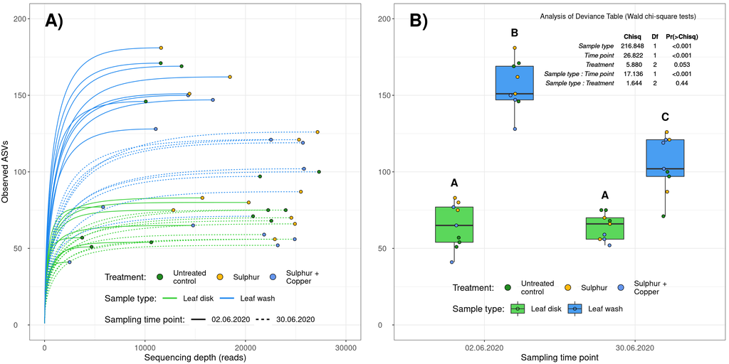

```r
rich.plot <- plot_grid(rASV, obs.plot, ncol=2)
rich.plot
```

```r
ggsave("./Figures/rich_plot.pdf", rich.plot, width = 14, height = 7)
```

# β-Diversity

### Calculate Jaccard distances and PERMANOVA

```r
factor.df <- as(sample_data(physeq.fungi), "data.frame")
factor.df$var1 <- row.names(factor.df)
factor.df$var2 <- row.names(factor.df)
dist.mat <- vegan::vegdist(t(as(otu_table(physeq.fungi),"matrix")),method = "jaccard", binary = TRUE)

set.seed(123)
permanova <- adonis(dist.mat ~ Sampletype * (Timepoint + Treatment), factor.df, strata=factor.df$Block)
permanova
```

```
##
## Call:
## adonis(formula = dist.mat ~ Sampletype * (Timepoint + Treatment),      data = factor.df, strata = factor.df$Block)
##
## Blocks:  strata
## Permutation: free
## Number of permutations: 999
##
## Terms added sequentially (first to last)
##
##                      Df SumsOfSqs MeanSqs F.Model      R2 Pr(>F)
## Sampletype            1    1.1539 1.15388  5.4646 0.11560  0.001 ***
## Timepoint             1    1.4535 1.45348  6.8834 0.14561  0.001 ***
## Treatment             2    0.5509 0.27547  1.3046 0.05519  0.094 .
## Sampletype:Timepoint  1    0.4430 0.44300  2.0980 0.04438  0.015 *
## Sampletype:Treatment  2    0.4683 0.23417  1.1090 0.04692  0.248
## Residuals            28    5.9124 0.21116         0.59230
## Total                35    9.9820                 1.00000
## ---
## Signif. codes:  0 '***' 0.001 '**' 0.01 '*' 0.05 '.' 0.1 ' ' 1
```

```r
perma_tab <- round(permanova[["aov.tab"]], digits = 3)
perma_tab <- perma_tab[,c(1,4,5,6)]
row.names(perma_tab) <- gsub("Sampletype", "Sample type", row.names(perma_tab))
row.names(perma_tab) <- gsub("Timepoint", "Time point", row.names(perma_tab))
row.names(perma_tab) <- gsub(":", " : ", row.names(perma_tab))
for (x in 1:(nrow(perma_tab)-2)) {
  if (as.numeric(perma_tab$`Pr(>F)`[x]) <= 0.001){
    perma_tab$`Pr(>F)`[x] <- paste("<0.001")
  }
}
perma_tab[is.na(perma_tab) == TRUE]  <- ""
```

### NMDS plot

```r
set.seed(123)
nmds <- metaMDS(dist.mat, k = 2, trymax = 100)
```

```
## *** Solution reached
```

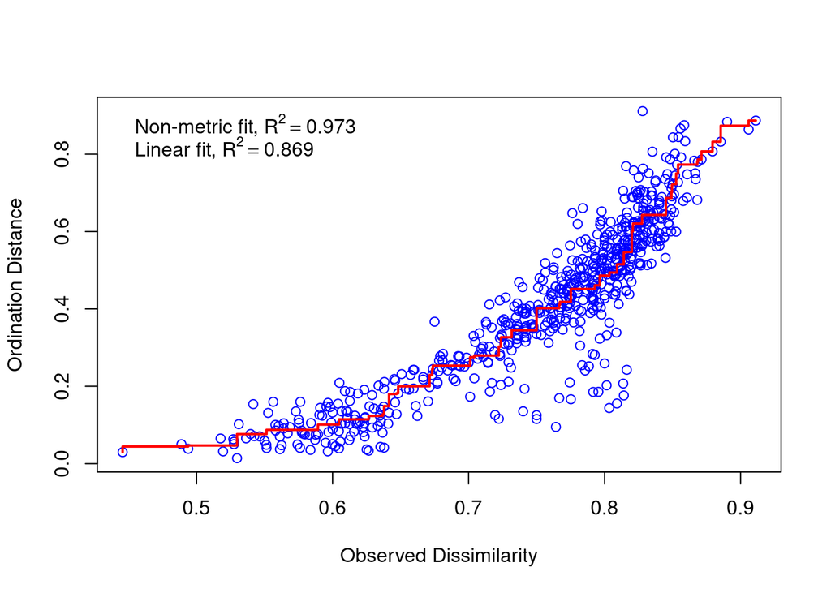

```r
stressplot(nmds)
```

```r
nmds.tab <- merge(scores(nmds), factor.df[,1:4], by= "row.names")
nmds.tab$Combi <- paste(nmds.tab$Sampletype, nmds.tab$Timepoint, sep = "_")

Leaf_2020_06_02 <- nmds.tab[nmds.tab$Combi == "Leaf_2020_06_02", ][chull(nmds.tab[nmds.tab$Combi == "Leaf_2020_06_02", c("NMDS1", "NMDS2")]), ]
Wash_2020_06_02 <- nmds.tab[nmds.tab$Combi == "Wash_2020_06_02", ][chull(nmds.tab[nmds.tab$Combi == "Wash_2020_06_02", c("NMDS1", "NMDS2")]), ]
Leaf_2020_06_30 <- nmds.tab[nmds.tab$Combi == "Leaf_2020_06_30", ][chull(nmds.tab[nmds.tab$Combi == "Leaf_2020_06_30", c("NMDS1", "NMDS2")]), ]
Wash_2020_06_30 <- nmds.tab[nmds.tab$Combi == "Wash_2020_06_30", ][chull(nmds.tab[nmds.tab$Combi == "Wash_2020_06_30", c("NMDS1", "NMDS2")]), ]

hull.data <- rbind(Leaf_2020_06_02, Wash_2020_06_02, Leaf_2020_06_30, Wash_2020_06_30)
hull.data$fill <- "color"
hull.data$fill[hull.data$Sampletype == "Wash"] <- "dodgerblue2"
hull.data$fill[hull.data$Sampletype == "Leaf"] <- "limegreen"

nmds.plot <- ggplot(mapping = aes(x = NMDS1, y = NMDS2))+
  geom_polygon(data=hull.data, aes(color = Combi, group = Combi),alpha = 0.8, fill = hull.data$fill)+
  geom_point(data = nmds.tab,
             mapping = aes(fill = factor(Treatment, levels = c("Cont", "S", "S_Cu")),
                           shape = factor(Combi, levels = c("Leaf_2020_06_02", "Leaf_2020_06_30", "Wash_2020_06_02", "Wash_2020_06_30"))),
             size = 3)+
  annotate(geom = "text", x = -1, y = 0.95, label = "A)",
           vjust = 0, hjust = 0, fontface='bold', size = 10)+
  annotate(geom = "text", x = -0.2, y = 1, label = "Permutational Multivariate Analysis of Variance Table",
           vjust = 0, hjust = 0)+
  annotate(geom = "table", x = -0.25, y = 0.41, label = list(perma_tab),
           vjust = 0, hjust = 0, table.rownames = TRUE, table.theme = ttheme_gtminimal(padding = unit(c(1, 0.6), "char")))+
  annotate(geom = "text", x = -1, y = 0.85, label = paste("  2D stress = ", round(nmds[["grstress"]], digits = 4)),
           vjust = 0, hjust = 0, size = 4)+

  scale_x_continuous(limits = c(-1,1))+
  scale_y_continuous(limits = c(-1,1))+
  scale_shape_manual(name = "Sample type and\nsampling time point:",
                     labels = c("Leaf disks - 02.06.2020", "Leaf disks - 30.06.2020", "Leaf wash - 02.06.2020", "Leaf wash - 30.06.2020"),
                     values = c(22,23,24,25))+
  scale_fill_manual(name = "\nTreatment:",
                    values = c("forestgreen", "darkgoldenrod1", "cornflowerblue"),
                    labels = c("Untreated\ncontrol", "Sulphur", "Sulphur + Copper"))+
  scale_color_manual(name = "Sample type and\nsampling time point:",
                     labels = c("Leaf disks - 02.06.2020", "Leaf disks - 30.06.2020", "Leaf wash - 02.06.2020", "Leaf wash - 30.06.2020"),
                     values = rep("black",4))+
  guides(fill=guide_legend(override.aes=list(shape=21, size = 5),
                           direction = "vertical", order = 2, ncol = 1),
         shape=guide_legend(direction = "vertical", order = 1, ncol = 1),
         color=guide_legend(override.aes=list(fill = c("limegreen", "limegreen", "dodgerblue2", "dodgerblue2"),
                                              shape=c(0,5,2,6)),
                            direction = "vertical", order = 1, ncol = 1))+

  theme_bw()+
  theme(plot.title = element_text(hjust = 0.5, vjust = 0, size = 16))+
  theme(axis.text.x = element_text(angle = +0, hjust = 0.5, vjust= 0, size = 12))+
  theme(axis.text.y = element_text(angle = +0, hjust = 0, vjust= 0.5, size = 12))+
  theme(axis.title.x = element_text(angle = +0, hjust = 0.5, vjust= 0, size = 14))+
  theme(axis.title.y = element_text(angle = +90, hjust = 0.5, vjust= 2, size = 14))+
  theme(legend.title = element_text(hjust = 0, vjust= 0.5, size = 14))+
  theme(legend.text = element_text(hjust = 0, vjust= 0.5, size = 12))+
  theme(legend.background = element_blank())+
  theme(legend.key.size = unit(0.7, "cm"))+
  theme(legend.spacing.x = unit(0.2, "cm"))+
  theme(legend.position= c(0.5,0.14))+
  theme(legend.box = "horizontal")
```

### Within-group Jaccard distances

```r
# Prepare table for Within-group Jaccard distances
dist.list <- list()
for (i in 1:(nrow(factor.df)-1)) {

  x = nrow(factor.df)-i

  if(i == 1){
    z = x
  }else if(i > 1){
    z = z+x
  }

  if(i == 1){
    y = nrow(factor.df)-z
  }else if(i > 1){
    y = y+x+1
  }
  df <- data.frame(var1 = rep(row.names(factor.df)[i],((nrow(factor.df)-1)-(i-1))),
                   var2 = row.names(factor.df)[-(1:i)],
                   value = dist.mat[y:z])
  df <- merge(df, factor.df, by = "var1", all.x = TRUE)
  df[,length(df)] <- NULL
  colnames(df)[2] <- "var2"
  df <- merge(df, factor.df, by = "var2", all.x = TRUE)

  dist.list[[i]] <- df

}

dist.tab <- bind_rows(dist.list)
dist.tab <- dist.tab[dist.tab$Sampletype.x == dist.tab$Sampletype.y,]
dist.tab <- dist.tab[dist.tab$Timepoint.x == dist.tab$Timepoint.y,]

row.names(dist.tab) <- 1:nrow(dist.tab)
dist.tab <- dist.tab[,1:7]
colnames(dist.tab) <- c("var2", "var1", "value", "Sampletype", "Timepoint", "Treatment", "Block")
dist.tab$Combi <- paste(dist.tab$Sampletype, dist.tab$Timepoint, sep = "_")

# Pairwise Wilcoxon Rank Sum Tests
wilcox <- pairwise.wilcox.test(dist.tab$value, dist.tab$Combi, p.adjust.method = "BH", paired = TRUE, var.equal = FALSE)
wilcox.tab <- make_cld(wilcox)
wilcox.tab$cld <- toupper(wilcox.tab$cld)

# Plot within-group distances
dist.plot <- ggplot(dist.tab, aes(x = Timepoint, y = value, fill = Sampletype))+
  geom_boxplot(position = position_dodge(width = 0.8), width = 0.5, alpha = 0.8)+
  geom_point(position = position_jitterdodge(dodge.width = 0.8, jitter.width = 0.1))+

  annotate(geom = "text", x = 0.5, y = 0.9825, label = "B)",
           vjust = 0, hjust = 0, fontface='bold', size = 10)+

  geom_text(x = c(0.77,1.17,1.77,2.17),
            y = c(max(dist.tab[dist.tab$Combi == "Leaf_2020_06_02",3]) + 0.03,
                  max(dist.tab[dist.tab$Combi == "Wash_2020_06_02",3]) + 0.03,
                  max(dist.tab[dist.tab$Combi == "Leaf_2020_06_30",3]) + 0.03,
                  max(dist.tab[dist.tab$Combi == "Wash_2020_06_30",3]) + 0.03),
            aes(label = cld, fill = NULL), vjust = 0, hjust = 0,
            data = wilcox.tab, fontface='bold', size = 6)+

  scale_fill_manual(name = "Sample type:",
                    values = c("limegreen", "dodgerblue2"),
                    labels = c("Leaf disk", "Leaf wash"),
                    guides(fill=guide_legend(direction = "horizontal", nrow = 1)))+
  scale_x_discrete(labels = c("02.06.2020", "30.06.2020"))+
  scale_y_continuous(limits = c(0.25,1))+

  labs(x= "Sampling time point", y = "Within-group Jaccard distances")+

  theme_bw()+
  theme(plot.title = element_text(hjust = 0.5, vjust = 0, size = 16))+
  theme(axis.text.x = element_text(angle = +0, hjust = 0.5, vjust= 0, size = 12))+
  theme(axis.text.y = element_text(angle = +0, hjust = 0, vjust= 0.5, size = 12))+
  theme(axis.title.x = element_text(angle = +0, hjust = 0.5, vjust= 0, size = 14))+
  theme(axis.title.y = element_text(angle = +90, hjust = 0.5, vjust= 2, size = 14))+
  theme(legend.title = element_text(hjust = 0, vjust= 0.5, size = 14))+
  theme(legend.text = element_text(hjust = 0, vjust= 0.5, size = 12))+
  theme(legend.background = element_blank())+
  theme(legend.key.size = unit(1, "cm"))+
  theme(legend.spacing = unit(-0.5, "cm"))+
  theme(legend.position= c(0.5,0.1))+
  theme(legend.direction = "horizontal")
```

### Combine β-Diversity plots

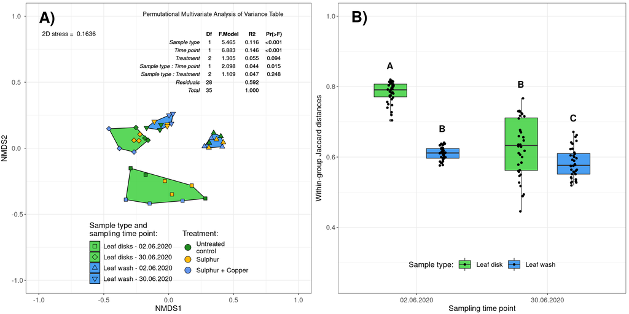

```r
beta.dist.plot <- plot_grid(nmds.plot, dist.plot, ncol=2)
beta.dist.plot
```

```r
ggsave("./Figures/beta.pdf", beta.dist.plot, width = 14, height = 7)
```

# Abundance of ASVs

#### Only samples with:

#### qPCR measured DNA >= conc. of last valid standard measurement

#### Metabarcoding counts >= 10

### Normalize metabarcoding counts for each sample type

```r
# Make metabarcoding count table
dds = phyloseq_to_deseq2(physeq.fungi, ~ Timepoint*Treatment+Block)
dds <- estimateSizeFactors(dds)
normalized_counts <- data.frame(round(counts(dds, normalized=TRUE)))
normalized_counts <- data.frame(t(normalized_counts))
```

### Function prepare qPCR data

```r
qPCR_analysis <- function(file, exclude){
  # make list
  list <- list()

  # load and filter data
  tab <- read.table(file, skip = 8, header =TRUE, sep ='\t')
  colnames(tab)[7] <- "Ct"
  tab$Ct <- as.numeric(as.character(tab$Ct))
  for (x in 1:(length(exclude))) {
    tab$Ct[tab$Well == exclude[x]] <- NA
  }

  ## prepare standard
  tab_std <- as_tibble(tab[tab$Task == "STANDARD", c(2,3,7,10)])
  by_sample <- group_by(tab_std, Sample.Name)
  tab_std_fixed <- summarise(by_sample,
                             mean_Ct = mean(Ct, na.rm = TRUE),
                             sd_Ct = sd(Ct, na.rm = TRUE),
                             quant = mean(Quantity, na.rm = TRUE))
  for (x in 1:(nrow(tab_std_fixed)-1)) {
    tab_std_fixed[x+1,4] <- tab_std_fixed[x,4]/10
  }
  tab_std_fixed <- tab_std_fixed[!(is.na(tab_std_fixed$mean_Ct)),]
  tab_std_fixed$log_quant <- log2(tab_std_fixed$quant)

  # make model
  std_mod <- lm(log_quant ~ mean_Ct, data = tab_std_fixed)
  tab_std_fixed$pred_quant <- 2^predict(std_mod)
  tab_std_fixed$log_pred_quant <- predict(std_mod)

  # check Std.
  ## log_quant vs. mean_Ct
  std_plot <- ggplot(tab_std_fixed, aes(x = mean_Ct, y = log_quant))+
    geom_smooth(method = "lm")+
    geom_errorbar(aes(xmin=mean_Ct-sd_Ct, xmax=mean_Ct+sd_Ct), size = 0.5, width = 0.25)+
    geom_point(size = 3)+
    stat_regline_equation(label.x=min(tab_std_fixed$mean_Ct), label.y=min(tab_std_fixed$log_quant)+2, size = 6)+
    stat_cor(aes(label = paste(..rr.label.., ..p.label.., sep = "~`,`~")), label.x=min(tab_std_fixed$mean_Ct), label.y=min(tab_std_fixed$log_quant), size = 6, r.digits = 3)

  # Add to list
  list[["Standard"]] <- tab_std_fixed
  list[["Standard.Plot"]] <- std_plot
  list[["Standard.Model"]] <- summary(std_mod)

  ## prepare sample table
  tab_samples <- data.frame(tab[tab$Task == "UNKNOWN", c(2,3,7)])
  tab_samples <- na.omit(tab_samples)
  by_sample <- group_by(tab_samples, Sample.Name)
  tab_samples <- summarise(by_sample,
                           tech_rep = n(),
                           mean_Ct = mean(Ct, na.rm = TRUE),
                           sd_Ct = sd(Ct, na.rm = TRUE))
  tab_samples$quantity <- 2^(predict(std_mod, newdata = data.frame(mean_Ct = tab_samples$mean_Ct)))
  tab_samples$log_quantity <- predict(std_mod, newdata = data.frame(mean_Ct = tab_samples$mean_Ct))
  tab_samples <- tab_samples[order(tab_samples$Sample.Name),]

  # Add to list
  list[["Samples"]] <- tab_samples

  return(list)
}
```

### Compare Metabarcoding and qPCR

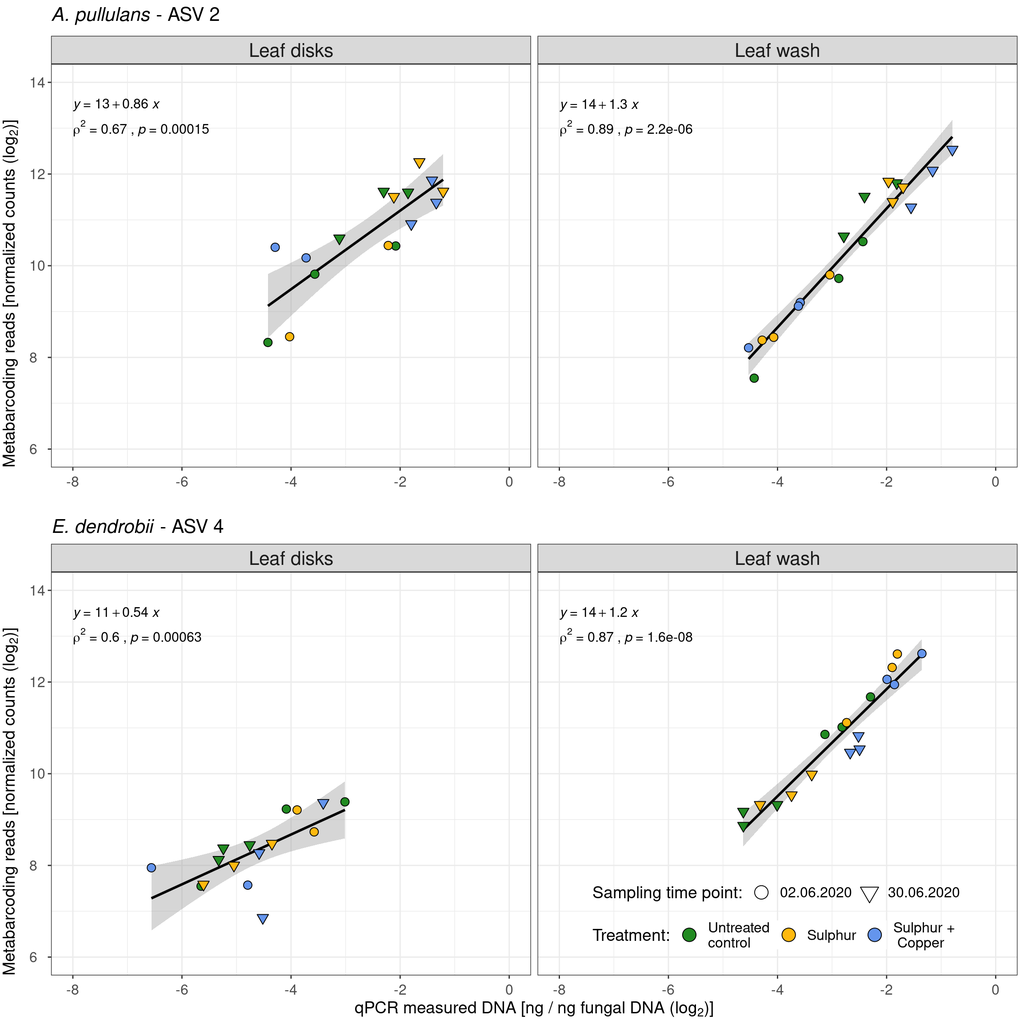

```r
# New lables for Sampletypes
Sampletype.labs <- c("Leaf disks", "Leaf wash")
names(Sampletype.labs) <- c("Leaf", "Wash")

# ITS qPCR reference plate 1
ITS1catta_1 <- qPCR_analysis('qpcr_ITS1_Neustadt_2020_leaf_data.txt', c("G7", "H7", "G8", "H8"))
its_qPCR_tab_1 <- ITS1catta_1[["Samples"]]
its_qPCR_tab_1 <- data.frame(ref_quantity = its_qPCR_tab_1$quantity,
                             log_ref_quantity = its_qPCR_tab_1$log_quantity,
                             row.names = its_qPCR_tab_1$Sample.Name)
its_qPCR_tab_1 <- its_qPCR_tab_1[its_qPCR_tab_1$ref_quantity >= ITS1catta_1[["Standard"]][["pred_quant"]][nrow(data.frame(ITS1catta_1[["Standard"]][["pred_quant"]]))],]

# ITS qPCR reference plate 2
ITS1catta_2 <- qPCR_analysis('qpcr_ITS1_Neustadt_2020_wash_data.txt', c("G7", "H7", "G8", "H8"))
its_qPCR_tab_2 <- ITS1catta_2[["Samples"]]
its_qPCR_tab_2 <- data.frame(ref_quantity = its_qPCR_tab_2$quantity,
                             log_ref_quantity = its_qPCR_tab_2$log_quantity,
                             row.names = its_qPCR_tab_2$Sample.Name)
its_qPCR_tab_2 <- its_qPCR_tab_2[its_qPCR_tab_2$ref_quantity >= ITS1catta_2[["Standard"]][["pred_quant"]][nrow(data.frame(ITS1catta_2[["Standard"]][["pred_quant"]]))],]

# Check correlation of standards of both plates
#summary(lm(ITS1catta_1[[1]]$mean_Ct ~ ITS1catta_2[[1]]$mean_Ct))
#summary(lm(ITS1catta_1[[1]]$log_pred_quant ~ ITS1catta_2[[1]]$log_pred_quant))

# Combine data of plates
its_qPCR_tab <- rbind(its_qPCR_tab_1, its_qPCR_tab_2)
its_qPCR_tab <- merge(its_qPCR_tab, data.frame(sample_data(physeq)), by = "row.names")
rownames(its_qPCR_tab) <- its_qPCR_tab$Row.names
its_qPCR_tab$Row.names <- NULL

## Analysis of individual ASVs
# ASV_2
apul_meta_tab <- data.frame(meta_counts = normalized_counts$ASV_2,
                            meta_counts_log = log2((normalized_counts$ASV_2)+1L),
                            row.names = row.names(normalized_counts))
apul_meta_tab <- apul_meta_tab[apul_meta_tab$meta_counts >= 10,]

# ASV_2 qPCR plate 1
apul_1 <- qPCR_analysis('qpcr_Apul_Neustadt_2020_leaf_data.txt', c("G8", "H8"))
apul_qPCR_tab_1 <- apul_1[["Samples"]]
apul_qPCR_tab_1 <- data.frame(target_quantity = apul_qPCR_tab_1$quantity,
                             log_target_quantity = apul_qPCR_tab_1$log_quantity,
                             row.names = apul_qPCR_tab_1$Sample.Name)
apul_qPCR_tab_1 <- apul_qPCR_tab_1[apul_qPCR_tab_1$target_quantity >= apul_1[["Standard"]][["pred_quant"]][nrow(data.frame(apul_1[["Standard"]][["pred_quant"]]))],]

# ASV_2 qPCR plate 2
apul_2 <- qPCR_analysis('qpcr_Apul_Neustadt_2020_wash_data.txt', c("G8", "H8"))
apul_qPCR_tab_2 <- apul_2[["Samples"]]
apul_qPCR_tab_2 <- data.frame(target_quantity = apul_qPCR_tab_2$quantity,
                             log_target_quantity = apul_qPCR_tab_2$log_quantity,
                             row.names = apul_qPCR_tab_2$Sample.Name)
apul_qPCR_tab_2 <- apul_qPCR_tab_2[apul_qPCR_tab_2$target_quantity >= apul_2[["Standard"]][["pred_quant"]][nrow(data.frame(apul_2[["Standard"]][["pred_quant"]]))],]

# Check correlation of standards of both plates
#summary(lm(apul_1[[1]]$mean_Ct ~ apul_2[[1]]$mean_Ct))
#summary(lm(apul_1[[1]]$log_pred_quant ~ apul_2[[1]]$log_pred_quant))

# Combine data of plates
apul_qPCR_tab <- rbind(apul_qPCR_tab_1, apul_qPCR_tab_2)
apul_tab <- merge(apul_qPCR_tab, its_qPCR_tab, by = "row.names")
row.names(apul_tab) <- apul_tab$Row.names
apul_tab$Row.names <- NULL
apul_tab$delta_target_qpcr <- apul_tab$target_quantity / apul_tab$ref_quantity
apul_tab$log_delta_target_qpcr <- log2(apul_tab$delta_target_qpcr)
apul_tab <- merge(apul_tab, apul_meta_tab, by = "row.names")
row.names(apul_tab) <- apul_tab$Row.names
apul_tab$Row.names <- NULL

apul_plot <- ggplot(data = apul_tab, mapping = aes(x = log_delta_target_qpcr, y = meta_counts_log))+
  geom_smooth(method = "lm", color = "black")+
  geom_point(mapping = aes(shape = factor(Timepoint, level = c("2020_06_02", "2020_06_30")), fill = factor(Treatment, level = c("Cont", "S", "S_Cu"))),
             size = 3)+
  facet_grid(~Sampletype, labeller = labeller(Sampletype = Sampletype.labs))+
  stat_regline_equation(label.x=-8, label.y=13.5 ,size = 4)+
  stat_cor(aes(label = paste(..rr.label.., ..p.label.., sep = "~`,`~")), method = "spearman", cor.coef.name = "rho", label.x=-8, label.y=13 ,size = 4)+

  scale_x_continuous(limits = c(-8,0), breaks = seq(-8,0,2))+
  scale_y_continuous(limits = c(6,14), breaks = seq(6,14,2))+

  scale_shape_manual(name = "Timepoint:",
                     labels = c("02.06.2020", "30.06.2020"),
                     values = c(21,25))+
  scale_fill_manual(name = "Treatment:",
                    values = c("forestgreen", "darkgoldenrod1", "cornflowerblue"),
                    labels = c("Untreated\ncontrol", "Sulphur", "Sulphur +\nCopper"))+

  labs(title = expression(italic("A. pullulans")* " - ASV 2"),
       x = "",
       y = expression("Metabarcoding reads [normalized counts (log"[2]*")]"))+

  guides(nrow= 2, fill=guide_legend(override.aes=list(shape=21)))+

  theme_bw()+
  theme(strip.text.x = element_text(size=16))+
  theme(plot.title = element_text(hjust = 0, size = 16))+
  theme(axis.text.x = element_text(angle = 0, hjust = 0.5, vjust= 0, size = 12))+
  theme(axis.text.y = element_text(angle = 0, hjust = 0, vjust= 0.5, size = 12))+
  theme(axis.title.x = element_text(angle = 0, hjust = 0.5, vjust= 0, size = 14))+
  theme(axis.title.y = element_text(angle = +90, hjust = 0, vjust= 2, size = 14))+
  theme(legend.position= c("none"))


# ASV_4
eden_meta_tab <- data.frame(meta_counts = normalized_counts$ASV_4,
                            meta_counts_log = log2((normalized_counts$ASV_4)+1L),
                            row.names = row.names(normalized_counts))
eden_meta_tab <- eden_meta_tab[eden_meta_tab$meta_counts >= 10,]

# ASV_4 qPCR plate 1
eden_1 <- qPCR_analysis('qpcr_Eden_Neustadt_2020_leaf_data.txt', c("B1", "B2", "B3", "A4", "A9", "F9",
                                                                   "G8", "H8"))
eden_qPCR_tab_1 <- eden_1[["Samples"]]
eden_qPCR_tab_1 <- data.frame(target_quantity = eden_qPCR_tab_1$quantity,
                             log_target_quantity = eden_qPCR_tab_1$log_quantity,
                             row.names = eden_qPCR_tab_1$Sample.Name)
eden_qPCR_tab_1 <- eden_qPCR_tab_1[eden_qPCR_tab_1$target_quantity >= eden_1[["Standard"]][["pred_quant"]][nrow(data.frame(eden_1[["Standard"]][["pred_quant"]]))],]

# ASV_4 qPCR plate 2
eden_2 <- qPCR_analysis('qpcr_Eden_Neustadt_2020_wash_data.txt', c("G8", "H8"))
eden_qPCR_tab_2 <- eden_2[["Samples"]]
eden_qPCR_tab_2 <- data.frame(target_quantity = eden_qPCR_tab_2$quantity,
                             log_target_quantity = eden_qPCR_tab_2$log_quantity,
                             row.names = eden_qPCR_tab_2$Sample.Name)
eden_qPCR_tab_2 <- eden_qPCR_tab_2[eden_qPCR_tab_2$target_quantity >= eden_2[["Standard"]][["pred_quant"]][nrow(data.frame(eden_2[["Standard"]][["pred_quant"]]))],]

# Check correlation of standards of both plates
#summary(lm(eden_1[[1]]$mean_Ct ~ eden_2[[1]]$mean_Ct))
#summary(lm(eden_1[[1]]$log_pred_quant ~ eden_2[[1]]$log_pred_quant))

# Combine data of plates
eden_qPCR_tab <- rbind(eden_qPCR_tab_1, eden_qPCR_tab_2)
eden_tab <- merge(eden_qPCR_tab, its_qPCR_tab, by = "row.names")
row.names(eden_tab) <- eden_tab$Row.names
eden_tab$Row.names <- NULL
eden_tab$delta_target_qpcr <- eden_tab$target_quantity / eden_tab$ref_quantity
eden_tab$log_delta_target_qpcr <- log2(eden_tab$delta_target_qpcr)
eden_tab <- merge(eden_tab, eden_meta_tab, by = "row.names")
row.names(eden_tab) <- eden_tab$Row.names
eden_tab$Row.names <- NULL


eden_plot <- ggplot(data = eden_tab, mapping = aes(x = log_delta_target_qpcr, y = meta_counts_log))+
  geom_smooth(method = "lm", color = "black")+
  geom_point(mapping = aes(shape = factor(Timepoint, level = c("2020_06_02", "2020_06_30")), fill = factor(Treatment, level = c("Cont", "S", "S_Cu"))),
             size = 3)+
  facet_grid(~Sampletype, labeller = labeller(Sampletype = Sampletype.labs))+
  stat_regline_equation(label.x=-8, label.y=13.5, size = 4)+
  stat_cor(aes(label = paste(..rr.label.., ..p.label.., sep = "~`,`~")), method = "spearman", cor.coef.name = "rho", label.x=-8, label.y=13, size = 4)+

  scale_shape_manual(values = c(21,25))+
  scale_fill_manual(values  = c("forestgreen","darkgoldenrod1", "cornflowerblue"))+
  scale_x_continuous(limits = c(-8,0), breaks = seq(-8,0,2))+
  scale_y_continuous(limits = c(6,14), breaks = seq(6,14,2))+

  labs(title = expression(italic("E. dendrobii")* " - ASV 4"),
       x = expression("qPCR measured DNA [ng / ng fungal DNA (log"[2]*")]"),
       y = expression("Metabarcoding reads [normalized counts (log"[2]*")]"))+

  scale_shape_manual(name = "Sampling time point:",
                     labels = c("02.06.2020", "30.06.2020"),
                     values = c(21,25))+
  scale_fill_manual(name = "Treatment:",
                    values = c("forestgreen", "darkgoldenrod1", "cornflowerblue"),
                    labels = c("Untreated\ncontrol", "Sulphur", "Sulphur +\n Copper"))+

  guides(fill=guide_legend(override.aes=list(shape=21, size = 5)),
         shape=guide_legend(override.aes=list(size = 5)),
         nrow= 2)+

  theme_bw()+
  theme(strip.text.x = element_text(size=16))+
  theme(plot.title = element_text(hjust = 0, size = 16))+
  theme(axis.text.x = element_text(angle = 0, hjust = 0.5, vjust= 0, size = 12))+
  theme(axis.text.y = element_text(angle = 0, hjust = 0, vjust= 0.5, size = 12))+
  theme(axis.title.x = element_text(angle = 0, hjust = 0.5, vjust= 0, size = 14))+
  theme(axis.title.y = element_text(angle = +90, hjust = 0, vjust= 2, size = 14))+
  theme(legend.title = element_text(hjust = 0, vjust= 0, size = 14))+
  theme(legend.title = element_text(hjust = 0, vjust= 0.5, size = 14))+
  theme(legend.text = element_text(hjust = 0, vjust= 0.5, size = 12))+
  theme(legend.background = element_blank())+
  theme(legend.position= c(0.75,0.15))+
  theme(legend.key.size = unit(0.7, "cm"))+
  theme(legend.spacing.x = unit(0.2, "cm"))+
  theme(legend.spacing.y = unit(0.1, "cm"))+
  theme(legend.direction = "horizontal", legend.box = "vertical")

# Plot ASV_2, ASV_4
plot <- plot_grid(apul_plot, eden_plot, ncol = 1)
plot
```

```r
ggsave("./Figures/corr_abundance.pdf", plot, width = 10, height = 10)
```

# Citations

```r
citation()
```

```
##
##
##   R Core Team (2020). R: A language and environment for statistical
##   computing. R Foundation for Statistical Computing, Vienna, Austria.
##   URL https://www.R-project.org/.
##
## A BibTeX entry for LaTeX users is
##
##   @Manual{,
##     title = {R: A Language and Environment for Statistical Computing},
##     author = {{R Core Team}},
##     organization = {R Foundation for Statistical Computing},
##     address = {Vienna, Austria},
##     year = {2020},
##     url = {https://www.R-project.org/},
##   }
##
## We have invested a lot of time and effort in creating R, please cite it
## when using it for data analysis. See also 'citation("pkgname")' for
## citing R packages.
```

```r
citation("tidyverse")
```

```
##
##   Wickham et al., (2019). Welcome to the tidyverse. Journal of Open
##   Source Software, 4(43), 1686, https://doi.org/10.21105/joss.01686
##
## A BibTeX entry for LaTeX users is
##
##   @Article{,
##     title = {Welcome to the {tidyverse}},
##     author = {Hadley Wickham and Mara Averick and Jennifer Bryan and Winston Chang and Lucy D'Agostino McGowan and Romain François and Garrett Grolemund and Alex Hayes and Lionel Henry and Jim Hester and Max Kuhn and Thomas Lin Pedersen and Evan Miller and Stephan Milton Bache and Kirill Müller a…
##     year = {2019},
##     journal = {Journal of Open Source Software},
##     volume = {4},
##     number = {43},
##     pages = {1686},
##     doi = {10.21105/joss.01686},
##   }
```

```r
citation("phyloseq")
```

```
##
##
##   phyloseq: An R package for reproducible interactive analysis and
##   graphics of microbiome census data. Paul J. McMurdie and Susan Holmes
##   (2013) PLoS ONE 8(4):e61217.
##
## A BibTeX entry for LaTeX users is
##
##   @Article{,
##     author = {Paul J. McMurdie and Susan Holmes},
##     journal = {PLoS ONE},
##     pages = {e61217},
##     title = {phyloseq: An R package for reproducible interactive analysis and graphics of microbiome census data},
##     volume = {8},
##     number = {4},
##     year = {2013},
##     url = {http://dx.plos.org/10.1371/journal.pone.0061217},
##   }
```

```r
citation("multcomp")
```

```
##
## A BibTeX entry for LaTeX users is
##
##   @Article{,
##     title = {Simultaneous Inference in General Parametric Models},
##     author = {Torsten Hothorn and Frank Bretz and Peter Westfall},
##     journal = {Biometrical Journal},
##     year = {2008},
##     volume = {50},
##     number = {3},
##     pages = {346--363},
##   }
```

```r
citation("ggpubr")
```

```
##
##
##   Alboukadel Kassambara (2020). ggpubr: 'ggplot2' Based Publication
##   Ready Plots. R package version 0.4.0.
##   https://CRAN.R-project.org/package=ggpubr
##
## A BibTeX entry for LaTeX users is
##
##   @Manual{,
##     title = {ggpubr: 'ggplot2' Based Publication Ready Plots},
##     author = {Alboukadel Kassambara},
##     year = {2020},
##     note = {R package version 0.4.0},
##     url = {https://CRAN.R-project.org/package=ggpubr},
##   }
```

```r
citation("vegan")
```

```
##
##
##   Jari Oksanen, F. Guillaume Blanchet, Michael Friendly, Roeland Kindt,
##   Pierre Legendre, Dan McGlinn, Peter R. Minchin, R. B. O'Hara, Gavin
##   L. Simpson, Peter Solymos, M. Henry H. Stevens, Eduard Szoecs and
##   Helene Wagner (2020). vegan: Community Ecology Package. R package
##   version 2.5-7. https://CRAN.R-project.org/package=vegan
##
## A BibTeX entry for LaTeX users is
##
##   @Manual{,
##     title = {vegan: Community Ecology Package},
##     author = {Jari Oksanen and F. Guillaume Blanchet and Michael Friendly and Roeland Kindt and Pierre Legendre and Dan McGlinn and Peter R. Minchin and R. B. O'Hara and Gavin L. Simpson and Peter Solymos and M. Henry H. Stevens and Eduard Szoecs and Helene Wagner},
##     year = {2020},
##     note = {R package version 2.5-7},
##     url = {https://CRAN.R-project.org/package=vegan},
##   }
##
## ATTENTION: This citation information has been auto-generated from the
## package DESCRIPTION file and may need manual editing, see
## 'help("citation")'.
```

```r
citation("ranacapa")
```

```
##
##
##   Gaurav Kandlikar (2021). ranacapa: Utility Functions and 'shiny' App
##   for Simple Environmental DNA Visualizations and Analyses. R package
##   version 0.1.0. https://github.com/gauravsk/ranacapa
##
## A BibTeX entry for LaTeX users is
##
##   @Manual{,
##     title = {ranacapa: Utility Functions and 'shiny' App for Simple Environmental DNA
## Visualizations and Analyses},
##     author = {Gaurav Kandlikar},
##     year = {2021},
##     note = {R package version 0.1.0},
##     url = {https://github.com/gauravsk/ranacapa},
##   }
```

```r
citation("cowplot")
```

```
##
##
##   Claus O. Wilke (2020). cowplot: Streamlined Plot Theme and Plot
##   Annotations for 'ggplot2'. R package version 1.1.1.
##   https://CRAN.R-project.org/package=cowplot
##
## A BibTeX entry for LaTeX users is
##
##   @Manual{,
##     title = {cowplot: Streamlined Plot Theme and Plot Annotations for 'ggplot2'},
##     author = {Claus O. Wilke},
##     year = {2020},
##     note = {R package version 1.1.1},
##     url = {https://CRAN.R-project.org/package=cowplot},
##   }
```

```r
citation("emmeans")
```

```
##
##
##   Russell V. Lenth (2021). emmeans: Estimated Marginal Means, aka
##   Least-Squares Means. R package version 1.6.2-1.
##   https://CRAN.R-project.org/package=emmeans
##
## A BibTeX entry for LaTeX users is
##
##   @Manual{,
##     title = {emmeans: Estimated Marginal Means, aka Least-Squares Means},
##     author = {Russell V. Lenth},
##     year = {2021},
##     note = {R package version 1.6.2-1},
##     url = {https://CRAN.R-project.org/package=emmeans},
##   }
```

```r
citation("ggpmisc")
```

```
##
##
##   Pedro J. Aphalo (2021). ggpmisc: Miscellaneous Extensions to
##   'ggplot2'. R package version 0.4.3.
##   https://CRAN.R-project.org/package=ggpmisc
##
## A BibTeX entry for LaTeX users is
##
##   @Manual{,
##     title = {ggpmisc: Miscellaneous Extensions to 'ggplot2'},
##     author = {Pedro J. Aphalo},
##     year = {2021},
##     note = {R package version 0.4.3},
##     url = {https://CRAN.R-project.org/package=ggpmisc},
##   }
```

```r
citation("lme4")
```

```
##
##
##   Douglas Bates, Martin Maechler, Ben Bolker, Steve Walker (2015).
##   Fitting Linear Mixed-Effects Models Using lme4. Journal of
##   Statistical Software, 67(1), 1-48. doi:10.18637/jss.v067.i01.
##
## A BibTeX entry for LaTeX users is
##
##   @Article{,
##     title = {Fitting Linear Mixed-Effects Models Using {lme4}},
##     author = {Douglas Bates and Martin M{\"a}chler and Ben Bolker and Steve Walker},
##     journal = {Journal of Statistical Software},
##     year = {2015},
##     volume = {67},
##     number = {1},
##     pages = {1--48},
##     doi = {10.18637/jss.v067.i01},
##   }
```

```r
citation("biostat")
```

```
##
##
##   Vilmantas Gegzna (2020). biostat: Routines for Basic (Bio)Statistics.
##   https://gegznav.github.io/biostat/,
##   https://github.com/gegznav/biostat/.
##
## A BibTeX entry for LaTeX users is
##
##   @Manual{,
##     title = {biostat: Routines for Basic (Bio)Statistics},
##     author = {Vilmantas Gegzna},
##     year = {2020},
##     note = {https://gegznav.github.io/biostat/,
## https://github.com/gegznav/biostat/},
##   }
```

```r
citation("DESeq2")
```

```
##
##   Love, M.I., Huber, W., Anders, S. Moderated estimation of fold change
##   and dispersion for RNA-seq data with DESeq2 Genome Biology 15(12):550
##   (2014)
##
## A BibTeX entry for LaTeX users is
##
##   @Article{,
##     title = {Moderated estimation of fold change and dispersion for RNA-seq data with DESeq2},
##     author = {Michael I. Love and Wolfgang Huber and Simon Anders},
##     year = {2014},
##     journal = {Genome Biology},
##     doi = {10.1186/s13059-014-0550-8},
##     volume = {15},
##     issue = {12},
##     pages = {550},
##   }
```